# Dataset Exploration Ford GoBike - Baywheels System

## Preliminary Wrangling

> This document will explore the Ford GoBike's trip data for public containing approximately 295854 bike rides for January 2020. "With a Ford GoBike membership, you get the first 45 minutes free, not just the first 30." With this report this will be an analysis of membership/subscriber usage and the duration of usuage for the launch of Ford GoBike now under Baywheels for 2020.

> Load in your dataset and describe its properties through the questions below. Try and motivate your exploration goals through this section.

```python
# import all packages and set plots to be embedded inline
import pandas as pd
import numpy as np
import matplotlib
from matplotlib import pyplot as plt
import matplotlib.ticker as tick
import seaborn as sb
import datetime
import math
import calendar
from requests import get
import os
import glob
import io


from IPython.display import Image

from bokeh.io import output_file, show, output_notebook
from bokeh.models import ColumnDataSource, GMapOptions
from bokeh.plotting import gmap, figure

%matplotlib inline
```

```python
#read dataframe
bikes_df = pd.read_csv('202001-baywheels-tripdata.csv')
```

## Assessing Data

```python
bikes_df.info()
```

```
<class 'pandas.core.frame.DataFrame'>
RangeIndex: 295854 entries, 0 to 295853
Data columns (total 15 columns):
duration_sec               295854 non-null int64
start_time                 295854 non-null object
end_time                   295854 non-null object
start_station_id           146286 non-null float64
start_station_name         146866 non-null object
start_station_latitude     295854 non-null float64
start_station_longitude    295854 non-null float64
end_station_id             145934 non-null float64
end_station_name           146511 non-null object
end_station_latitude       295854 non-null float64
end_station_longitude      295854 non-null float64
bike_id                    295854 non-null int64
user_type                  295854 non-null object
bike_share_for_all_trip    110108 non-null object
rental_access_method       185746 non-null object
dtypes: float64(6), int64(2), object(7)
memory usage: 33.9+ MB
```

```python
bikes_df.describe()
```

|  | duration_sec | start_station_id | start_station_latitude | start_station_longitude | end_station_id | end_station_latitude | end_station_longitude | bike_id |
| --- | --- | --- | --- | --- | --- | --- | --- | --- |
| count | 295854.000000 | 146286.000000 | 295854.000000 | 295854.000000 | 145934.000000 | 295854.000000 | 295854.000000 | 295854.00000 |
| mean | 780.473193 | 168.900879 | 37.751277 | -122.357866 | 161.061788 | 37.751261 | -122.356994 | 321533.84539 |
| std | 2037.786317 | 141.956388 | 0.228337 | 0.650796 | 140.766154 | 0.238642 | 0.688512 | 307015.31534 |
| min | 60.000000 | 3.000000 | 0.000000 | -122.513871 | 3.000000 | 0.000000 | -122.513847 | 12.00000 |
| 25% | 369.000000 | 53.000000 | 37.766214 | -122.419481 | 43.000000 | 37.766376 | -122.418306 | 11328.00000 |
| 50% | 588.000000 | 120.000000 | 37.777158 | -122.403234 | 113.000000 | 37.777370 | -122.402717 | 279974.00000 |
| 75% | 912.000000 | 263.000000 | 37.790102 | -122.392450 | 250.000000 | 37.790492 | -122.392546 | 545607.00000 |
| max | 811077.000000 | 506.000000 | 37.880222 | 0.000000 | 506.000000 | 37.927622 | 0.000000 | 999952.00000 |

```python
bikes_df.head(2)
```

|  | duration_sec | start_time | end_time | start_station_id | start_station_name | start_station_latitude | start_station_longitude | end_station_id | end_station_name | end_station_latitude | end_station_longitude | bike_id | user_type | bike_share_for_all_trip | rental_access_method |
| --- | --- | --- | --- | --- | --- | --- | --- | --- | --- | --- | --- | --- | --- | --- | --- |
| 0 | 83118 | 2020-01-31 15:23:47.7330 | 2020-02-01 14:29:06.2630 | 400.0 | Buchanan St at North Point St | 37.804272 | -122.433537 | 400.0 | Buchanan St at North Point St | 37.804272 | -122.433537 | 13052 | Customer | No | NaN |
| 1 | 68239 | 2020-01-31 15:40:31.6160 | 2020-02-01 10:37:51.0000 | 99.0 | Folsom St at 15th St | 37.767037 | -122.415443 | 99.0 | Folsom St at 15th St | 37.767037 | -122.415443 | 12235 | Subscriber | Yes | NaN |

```python
bikes_df.duplicated().sum()
```

```
0
```

```python
bikes_df['user_type'].value_counts()
```

```
Subscriber    170988
Customer      124866
Name: user_type, dtype: int64
```

```python
bikes_df['start_station_name'].value_counts()
```

```
Market St at 10th St                                               2753
San Francisco Caltrain (Townsend St at 4th St)                     2734
Berry St at 4th St                                                 2638
Howard St at Beale St                                              2076
San Francisco Ferry Building (Harry Bridges Plaza)                 1998
Powell St BART Station (Market St at 4th St)                       1736
Montgomery St BART Station (Market St at 2nd St)                   1654
Powell St BART Station (Market St at 5th St)                       1634
Market St at Steuart St                                            1373
4th St at 16th St                                                  1276
Embarcadero BART Station (Beale St at Market St)                   1260
2nd St at Townsend St                                              1213
Salesforce Transit Center (Natoma St at 2nd St)                    1199
Beale St at Harrison St                                            1188
Rhode Island St at 17th St                                         1172
Townsend St at 5th St                                              1137
San Francisco Public Library (Grove St at Hyde St)                 1121
3rd St at Townsend St                                              1094
San Francisco Caltrain Station (King St at 4th St)                 1091
Townsend St at 7th St                                              1083
16th St Mission BART Station 2                                     1017
4th St at Mission Bay Blvd S                                       1004
The Embarcadero at Sansome St                                       998
Civic Center/UN Plaza BART Station (Market St at McAllister St)     989
Howard St at 8th St                                                 963
The Embarcadero at Steuart St                                       929
8th St at Brannan St                                                895
Post St at Kearny St                                                885
Bancroft Way at College Ave                                         871
19th Street BART Station                                            862
                                                                   ...
Parkmoor Ave at Race St                                              17
Stockton Ave at Lenzen Ave                                           16
Williams Ave at 3rd St                                               15
Carroll Ave at 3rd St                                                15
Sonora Ave at 1st St                                                 15
George St at 1st St                                                  15
Gish Rd at 1st St                                                    15
Lane St at Revere Ave                                                15
26th Ave at International Blvd                                       14
21st St at Santa Clara St                                            12
Evans Ave at Mendell St                                              12
Willow St at Vine St                                                 12
Newbury Park Dr at King Rd                                           12
Foothill Blvd at Harrington Ave                                      12
Locust St at Grant St                                                11
Bird Ave at Coe Ave                                                  10
10th St at Empire St                                                 10
Oak St at 1st St                                                     10
Palm St at Willow St                                                  9
16th Depot Bike Fleet Station                                         8
Backesto Park (Jackson St at 13th St)                                 8
Jennings St at Revere Ave                                             7
7th St at Empire St                                                   7
Fruitvale Ave at International Blvd                                   6
1st St at Younger Ave                                                 6
23rd St at Taylor St                                                  4
Columbia Ave at Bird Ave                                              4
7th Ave at Clement St                                                 4
San Jose Depot                                                        1
Egbert Ave at Jennings St                                             1
Name: start_station_name, Length: 430, dtype: int64
```

## Cleaning Data

### Define

1. start_station_id and end_station_id should be string
2. start_time and end_time are objects and should be datetime
3. user_type should be category
4. bike_share_for_all_trip should be category
5. Obtain Start month name, month number, weekday
6. Obtain End month name, month number, weekday
7. Obtain duration hours and min

```python
# make copies of the dataframes for cleaning

bikes_df_clean = bikes_df.copy()
```

## Test

```python
bikes_df_clean.info()
```

```
<class 'pandas.core.frame.DataFrame'>
RangeIndex: 295854 entries, 0 to 295853
Data columns (total 15 columns):
duration_sec               295854 non-null int64
start_time                 295854 non-null object
end_time                   295854 non-null object
start_station_id           146286 non-null float64
start_station_name         146866 non-null object
start_station_latitude     295854 non-null float64
start_station_longitude    295854 non-null float64
end_station_id             145934 non-null float64
end_station_name           146511 non-null object
end_station_latitude       295854 non-null float64
end_station_longitude      295854 non-null float64
bike_id                    295854 non-null int64
user_type                  295854 non-null object
bike_share_for_all_trip    110108 non-null object
rental_access_method       185746 non-null object
dtypes: float64(6), int64(2), object(7)
memory usage: 33.9+ MB
```

```python
# Change bike_id, Start_station_id and end_station_id to string
bikes_df_clean.bike_id = bikes_df_clean.bike_id.astype(str)
bikes_df_clean.start_station_id = bikes_df_clean.bike_id.astype(str)
bikes_df_clean.end_station_id = bikes_df_clean.bike_id.astype(str)
```

## Test

```python
bikes_df_clean.info()
```

```
<class 'pandas.core.frame.DataFrame'>
RangeIndex: 295854 entries, 0 to 295853
Data columns (total 15 columns):
duration_sec               295854 non-null int64
start_time                 295854 non-null object
end_time                   295854 non-null object
start_station_id           295854 non-null object
start_station_name         146866 non-null object
start_station_latitude     295854 non-null float64
start_station_longitude    295854 non-null float64
end_station_id             295854 non-null object
end_station_name           146511 non-null object
end_station_latitude       295854 non-null float64
end_station_longitude      295854 non-null float64
bike_id                    295854 non-null object
user_type                  295854 non-null object
bike_share_for_all_trip    110108 non-null object
rental_access_method       185746 non-null object
dtypes: float64(4), int64(1), object(10)
memory usage: 33.9+ MB
```

```python
bikes_df_clean.start_time = pd.to_datetime(bikes_df_clean.start_time)
bikes_df_clean.end_time = pd.to_datetime(bikes_df_clean.end_time)
```

## Test

```python
bikes_df_clean.info()
```

```
<class 'pandas.core.frame.DataFrame'>
RangeIndex: 295854 entries, 0 to 295853
Data columns (total 15 columns):
duration_sec               295854 non-null int64
start_time                 295854 non-null datetime64[ns]
end_time                   295854 non-null datetime64[ns]
start_station_id           295854 non-null object
start_station_name         146866 non-null object
start_station_latitude     295854 non-null float64
start_station_longitude    295854 non-null float64
end_station_id             295854 non-null object
end_station_name           146511 non-null object
end_station_latitude       295854 non-null float64
end_station_longitude      295854 non-null float64
bike_id                    295854 non-null object
user_type                  295854 non-null object
bike_share_for_all_trip    110108 non-null object
rental_access_method       185746 non-null object
dtypes: datetime64[ns](2), float64(4), int64(1), object(8)
memory usage: 33.9+ MB
```

```python
#Change user_type to caegory
bikes_df_clean.user_type = bikes_df_clean.user_type.astype('category')
```

## Test

```python
bikes_df_clean.info()
```

```
<class 'pandas.core.frame.DataFrame'>
RangeIndex: 295854 entries, 0 to 295853
Data columns (total 15 columns):
duration_sec               295854 non-null int64
start_time                 295854 non-null datetime64[ns]
end_time                   295854 non-null datetime64[ns]
start_station_id           295854 non-null object
start_station_name         146866 non-null object
start_station_latitude     295854 non-null float64
start_station_longitude    295854 non-null float64
end_station_id             295854 non-null object
end_station_name           146511 non-null object
end_station_latitude       295854 non-null float64
end_station_longitude      295854 non-null float64
bike_id                    295854 non-null object
user_type                  295854 non-null category
bike_share_for_all_trip    110108 non-null object
rental_access_method       185746 non-null object
dtypes: category(1), datetime64[ns](2), float64(4), int64(1), object(7)
memory usage: 31.9+ MB
```

```python
#Change bike_share_for_all_trip to category
bikes_df_clean.bike_share_for_all_trip = bikes_df_clean.bike_share_for_all_trip.astype('category')
```

```python
bikes_df_clean.info()
```

```
<class 'pandas.core.frame.DataFrame'>
RangeIndex: 295854 entries, 0 to 295853
Data columns (total 15 columns):
duration_sec               295854 non-null int64
start_time                 295854 non-null datetime64[ns]
end_time                   295854 non-null datetime64[ns]
start_station_id           295854 non-null object
start_station_name         146866 non-null object
start_station_latitude     295854 non-null float64
start_station_longitude    295854 non-null float64
end_station_id             295854 non-null object
end_station_name           146511 non-null object
end_station_latitude       295854 non-null float64
end_station_longitude      295854 non-null float64
bike_id                    295854 non-null object
user_type                  295854 non-null category
bike_share_for_all_trip    110108 non-null category
rental_access_method       185746 non-null object
dtypes: category(2), datetime64[ns](2), float64(4), int64(1), object(6)
memory usage: 29.9+ MB
```

```python
# extract start time month name
bikes_df_clean['start_time_month_name']=bikes_df_clean['start_time'].dt.strftime('%B')
```

```python
# extract start time month number
bikes_df_clean['start_time_month']=bikes_df_clean['start_time'].dt.month.astype(int)
```

```python
# extract start time weekdays
bikes_df_clean['start_time_weekday']=bikes_df_clean['start_time'].dt.strftime('%a')
```

## Test

```python
bikes_df_clean.head(1)
```

|  | duration_sec | start_time | end_time | start_station_id | start_station_name | start_station_latitude | start_station_longitude | end_station_id | end_station_name | end_station_latitude | end_station_longitude | bike_id | user_type | bike_share_for_all_trip | rental_access_method | start_time_month_name | start_time_month | start_time_weekday |
| --- | --- | --- | --- | --- | --- | --- | --- | --- | --- | --- | --- | --- | --- | --- | --- | --- | --- | --- |
| 0 | 83118 | 2020-01-31 15:23:47.733 | 2020-02-01 14:29:06.263 | 13052 | Buchanan St at North Point St | 37.804272 | -122.433537 | 13052 | Buchanan St at North Point St | 37.804272 | -122.433537 | 13052 | Customer | No | NaN | January | 1 | Fri |

```python
# extract end time month name
bikes_df_clean['end_time_month_name']=bikes_df_clean['end_time'].dt.strftime('%B')
```

```python
# extract end time month number
bikes_df_clean['end_time_month']=bikes_df_clean['end_time'].dt.month.astype(int)
```

```python
# extract end time weekdays
bikes_df_clean['end_time_weekday']=bikes_df_clean['end_time'].dt.strftime('%a')
```

## Test

```python
bikes_df_clean.head(1)
```

|  | duration_sec | start_time | end_time | start_station_id | start_station_name | start_station_latitude | start_station_longitude | end_station_id | end_station_name | end_station_latitude | ... | bike_id | user_type | bike_share_for_all_trip | rental_access_method | start_time_month_name | start_time_month | start_time_weekday | end_time_month_name | end_time_month | end_time_weekday |
| --- | --- | --- | --- | --- | --- | --- | --- | --- | --- | --- | --- | --- | --- | --- | --- | --- | --- | --- | --- | --- | --- |
| 0 | 83118 | 2020-01-31 15:23:47.733 | 2020-02-01 14:29:06.263 | 13052 | Buchanan St at North Point St | 37.804272 | -122.433537 | 13052 | Buchanan St at North Point St | 37.804272 | ... | 13052 | Customer | No | NaN | January | 1 | Fri | February | 2 | Sat |

1 rows × 21 columns

```python
# Create new categories for duration_min, duration_hr
bikes_df_clean['duration_min']=bikes_df_clean['duration_sec']/60
bikes_df_clean['duration_hr']=bikes_df_clean['duration_min']/60
bikes_df_clean['duration_min']=bikes_df_clean['duration_min'].astype(float)
bikes_df_clean['duration_hr']=bikes_df_clean['duration_hr'].astype(float)
```

## Test

```python
bikes_df_clean.head(2)
```

|  | duration_sec | start_time | end_time | start_station_id | start_station_name | start_station_latitude | start_station_longitude | end_station_id | end_station_name | end_station_latitude | ... | bike_share_for_all_trip | rental_access_method | start_time_month_name | start_time_month | start_time_weekday | end_time_month_name | end_time_month | end_time_weekday | duration_min | duration_hr |
| --- | --- | --- | --- | --- | --- | --- | --- | --- | --- | --- | --- | --- | --- | --- | --- | --- | --- | --- | --- | --- | --- |
| 0 | 83118 | 2020-01-31 15:23:47.733 | 2020-02-01 14:29:06.263 | 13052 | Buchanan St at North Point St | 37.804272 | -122.433537 | 13052 | Buchanan St at North Point St | 37.804272 | ... | No | NaN | January | 1 | Fri | February | 2 | Sat | 1385.300000 | 23.088333 |
| 1 | 68239 | 2020-01-31 15:40:31.616 | 2020-02-01 10:37:51.000 | 12235 | Folsom St at 15th St | 37.767037 | -122.415443 | 12235 | Folsom St at 15th St | 37.767037 | ... | Yes | NaN | January | 1 | Fri | February | 2 | Sat | 1137.316667 | 18.955278 |

2 rows × 23 columns

### What is the structure of your dataset?

> Looking at the January 2020 data there are 295,854 bike rides for the San Francisco Bay area. The data contains the following information: Trip Duration- start and end times Station bikes start and end with names Bike Ids User Type

> The dataframe was updated to further include in addtion to the start and end date columns breaking this data for further analysis into Month and Weekday

### What is/are the main feature(s) of interest in your dataset?

> Looking through the data I plan to provide a report for bike users for 2020 to help provide a look at the start for the first month trends for future forecasting. This will include looking into the following:
1. Bike demand for weekday for the first month report, and for furutre schedule planning
2. The current duration of time spent on bikes
3. The users type- subscriber vs customer
4. Top most popular start and end locations

### What features in the dataset do you think will help support your investigation into your feature(s) of interest?

> I feel Friday through Sunday maybe the strongest days bikes are being used. Validating if our current subscribers are using bikes more or do subscription oppurtunties need to be reviewed on presentation. From the data I expect to see Ford GoBike's strongest locations.

## Univariate Exploration

> In this section, investigate distributions of individual variables. If you see unusual points or outliers, take a deeper look to clean things up and prepare yourself to look at relationships between variables.

```python
bikes_df_clean.info()
```

```
<class 'pandas.core.frame.DataFrame'>
RangeIndex: 295854 entries, 0 to 295853
Data columns (total 23 columns):
duration_sec               295854 non-null int64
start_time                 295854 non-null datetime64[ns]
end_time                   295854 non-null datetime64[ns]
start_station_id           295854 non-null object
start_station_name         146866 non-null object
start_station_latitude     295854 non-null float64
start_station_longitude    295854 non-null float64
end_station_id             295854 non-null object
end_station_name           146511 non-null object
end_station_latitude       295854 non-null float64
end_station_longitude      295854 non-null float64
bike_id                    295854 non-null object
user_type                  295854 non-null category
bike_share_for_all_trip    110108 non-null category
rental_access_method       185746 non-null object
start_time_month_name      295854 non-null object
start_time_month           295854 non-null int32
start_time_weekday         295854 non-null object
end_time_month_name        295854 non-null object
end_time_month             295854 non-null int32
end_time_weekday           295854 non-null object
duration_min               295854 non-null float64
duration_hr                295854 non-null float64
dtypes: category(2), datetime64[ns](2), float64(6), int32(2), int64(1), object(10)
memory usage: 45.7+ MB
```

## Weekday bike demand

```python
bikes_df_clean['start_time_weekday'].value_counts()
```

```
Fri    56258
Wed    52737
Thu    51284
Tue    41967
Mon    39690
Sat    28496
Sun    25422
Name: start_time_weekday, dtype: int64
```

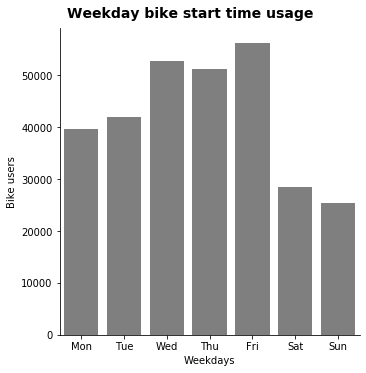

```python
# create a list for weekday which we will use through out the exploration
base_color = sb.color_palette()[7]
weekday = ['Mon', 'Tue', 'Wed', 'Thu', 'Fri', 'Sat', 'Sun']
# plot start time usage
g = sb.catplot(data=bikes_df_clean, x='start_time_weekday', kind='count', color = base_color, order = weekday)
g.set_axis_labels("Weekdays", "Bike users")
g.fig.suptitle('Weekday bike start time usage', y=1.03, fontsize=14, fontweight='semibold');
```

```python
bikes_df_clean['end_time_weekday'].value_counts()
```

```
Fri    56195
Wed    52730
Thu    51276
Tue    41953
Mon    39682
Sat    28516
Sun    25502
Name: end_time_weekday, dtype: int64
```

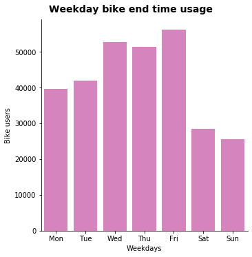

```python
# create a list for weekday which we will use through out the exploration
base_color = sb.color_palette()[6]
weekday = ['Mon', 'Tue', 'Wed', 'Thu', 'Fri', 'Sat', 'Sun']
# plot end time usage
g = sb.catplot(data=bikes_df_clean, x='end_time_weekday', kind='count', color = base_color, order = weekday)
g.set_axis_labels("Weekdays", "Bike users")
g.fig.suptitle('Weekday bike end time usage', y=1.03, fontsize=14, fontweight='semibold');
```

## Conclusion

Showing Friday to be the highest day for bike rentals. Followed by Wednesday and Thursday

## Duration of time

```python
bikes_df_clean.duration_sec.describe()
```

```
count    295854.000000
mean        780.473193
std        2037.786317
min          60.000000
25%         369.000000
50%         588.000000
75%         912.000000
max      811077.000000
Name: duration_sec, dtype: float64
```

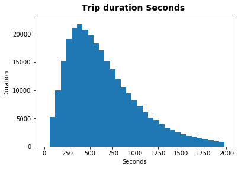

```python
#plotting a hist for duration of Seconds
bin_edges = np.arange(0, 2000,60)

plt.hist(data = bikes_df_clean, x = 'duration_sec', bins = bin_edges)

plt.title("Trip duration Seconds ", y=1.03, fontsize=14, fontweight='semibold')
plt.xlabel('Seconds')
plt.ylabel('Duration ');
```

```python
bikes_df_clean.duration_min.describe()
```

```
count    295854.000000
mean         13.007887
std          33.963105
min           1.000000
25%           6.150000
50%           9.800000
75%          15.200000
max       13517.950000
Name: duration_min, dtype: float64
```

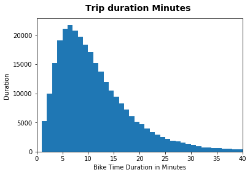

```python
#plotting a hist for duration of minutes
bins = np.arange(0, bikes_df_clean['duration_min'].max()+1, 1)
plt.hist(data = bikes_df_clean, x = 'duration_min', bins = bins)
plt.xlim([0,40])
plt.title("Trip duration Minutes ", y=1.03, fontsize=14, fontweight='semibold')
plt.xlabel('Bike Time Duration in Minutes')
plt.ylabel('Duration ')
plt.show()
```

```python
bikes_df_clean.duration_hr.describe()
```

```
count    295854.000000
mean          0.216798
std           0.566052
min           0.016667
25%           0.102500
50%           0.163333
75%           0.253333
max         225.299167
Name: duration_hr, dtype: float64
```

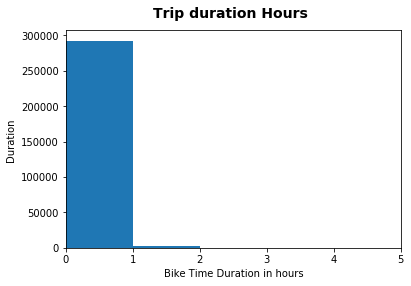

```python
#plotting a hist for duration of hours
bins = np.arange(0, bikes_df_clean['duration_hr'].max()+1, 1)
plt.hist(data = bikes_df_clean, x = 'duration_hr', bins = bins)
plt.xlim([0,5])
plt.title("Trip duration Hours ", y=1.03, fontsize=14, fontweight='semibold')
plt.xlabel('Bike Time Duration in hours')
plt.ylabel('Duration ')
plt.show()
```

```python
bikes_df_clean['end_time_month_name'].value_counts()
```

```
January     295789
February        65
Name: end_time_month_name, dtype: int64
```

## Customer vs Subscriber

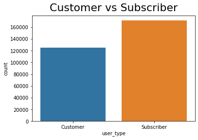

```python
#plotting the user_types
sb.countplot(data=bikes_df_clean,x='user_type');
plt.title('Customer vs Subscriber', fontsize=22, y=1.015);
```

```python
bikes_df_clean['user_type'].value_counts()
```

```
Subscriber    170988
Customer      124866
Name: user_type, dtype: int64
```

## Conclusion

### Subscribers are more frequent at 170,988 vs Customers at 124,866

## Most popular start and end loactions

```python
#obtain the top ten popular start destionations
bikes_df_clean['start_station_name'].value_counts().head(10)
```

```
Market St at 10th St                                  2753
San Francisco Caltrain (Townsend St at 4th St)        2734
Berry St at 4th St                                    2638
Howard St at Beale St                                 2076
San Francisco Ferry Building (Harry Bridges Plaza)    1998
Powell St BART Station (Market St at 4th St)          1736
Montgomery St BART Station (Market St at 2nd St)      1654
Powell St BART Station (Market St at 5th St)          1634
Market St at Steuart St                               1373
4th St at 16th St                                     1276
Name: start_station_name, dtype: int64
```

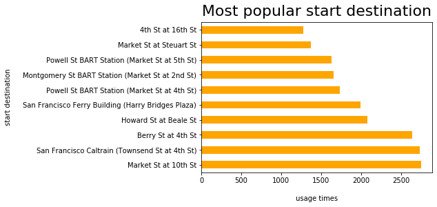

```python
#plot the top ten popular start destionations
bikes_df_clean['start_station_name'].value_counts().head(10).plot(kind='barh', color= "orange");
plt.title('Most popular start destination', fontsize=22, y=1.015)
plt.xlabel('usage times', labelpad=16)
plt.ylabel('start destination', labelpad=16);
```

## Conclusion

Most popular start destination Market St at 10th St

```python
#obtain the top ten popular end destionations
bikes_df_clean['end_station_name'].value_counts().head(10)
```

```
San Francisco Caltrain (Townsend St at 4th St)        5023
Montgomery St BART Station (Market St at 2nd St)      2888
Berry St at 4th St                                    2851
San Francisco Ferry Building (Harry Bridges Plaza)    2835
Market St at 10th St                                  2723
Powell St BART Station (Market St at 4th St)          2076
Howard St at Beale St                                 1979
Powell St BART Station (Market St at 5th St)          1699
Market St at Steuart St                               1510
Embarcadero BART Station (Beale St at Market St)      1366
Name: end_station_name, dtype: int64
```

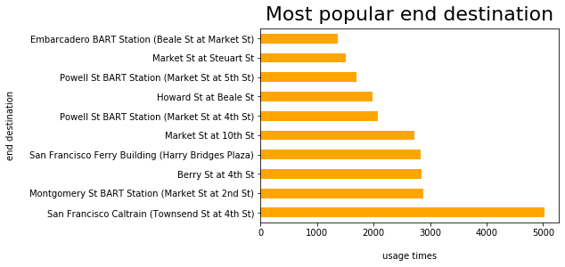

```python
#plot the top ten popular end destionations
bikes_df_clean['end_station_name'].value_counts().head(10).plot(kind='barh', color= "orange");
plt.title('Most popular end destination', fontsize=22, y=1.015)
plt.xlabel('usage times', labelpad=16)
plt.ylabel('end destination', labelpad=16);
```

## Conclusion

Most popular end destination San Francisco Caltrain (Townsend St at 4th St)

### Discuss the distribution(s) of your variable(s) of interest. Were there any unusual points? Did you need to perform any transformations?

> For duration I used different max range's to help display data. Seconds= 2000, Minutes = 40, and hours = 5. Also to display weekday's in order I made a list weekday = ['Mon', 'Tue', 'Wed', 'Thu', 'Fri', 'Sat', 'Sun']

## Bivariate Exploration

> In this section, investigate relationships between pairs of variables in your data. Make sure the variables that you cover here have been introduced in some fashion in the previous section (univariate exploration).

## Customer vs Subscriber weekday usage

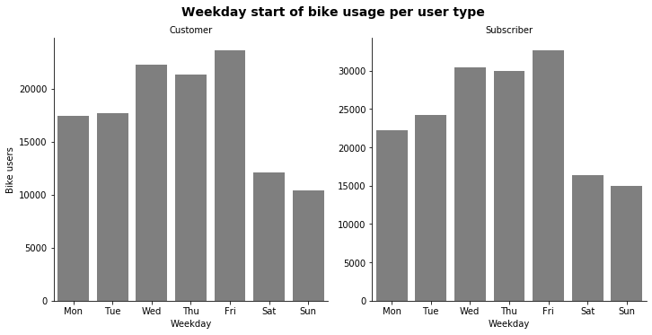

```python
# Weekday start usage of bikes per user type
base_color = sb.color_palette()[7]
weekday = ['Mon', 'Tue', 'Wed', 'Thu', 'Fri', 'Sat', 'Sun']
g = sb.catplot(data=bikes_df_clean, x='start_time_weekday', col="user_type", kind='count', sharey = False,
            color = base_color, order = weekday)
g.set_axis_labels("Weekday", "Bike users")
g.set_titles("{col_name}")
g.fig.suptitle('Weekday start of bike usage per user type', y=1.03, fontsize=14, fontweight='semibold');
```

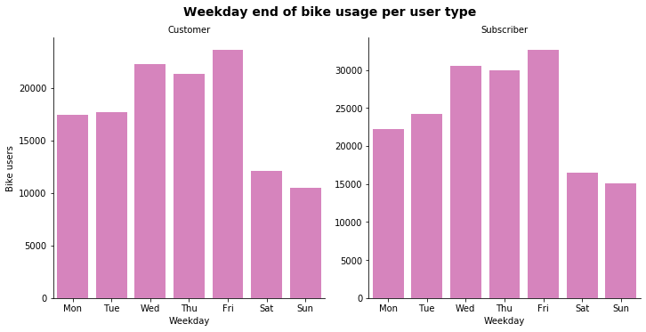

```python
# Weekday end of bike usage per user type
base_color = sb.color_palette()[6]
weekday = ['Mon', 'Tue', 'Wed', 'Thu', 'Fri', 'Sat', 'Sun']
g = sb.catplot(data=bikes_df_clean, x='end_time_weekday', col="user_type", kind='count', sharey = False,
            color = base_color, order = weekday)
g.set_axis_labels("Weekday", "Bike users")
g.set_titles("{col_name}")
g.fig.suptitle('Weekday end of bike usage per user type', y=1.03, fontsize=14, fontweight='semibold');
```

## Conclusion

For both customers and Subscribers a spike in mid week usage if seen with Friday being hiest followed by Wednesday and Thursday

## Bike duration per user type

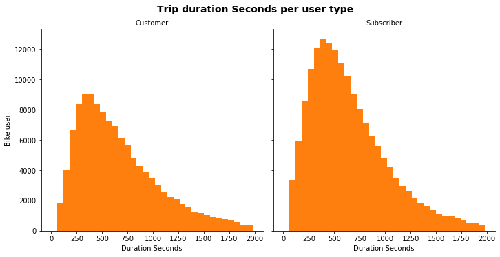

```python
# bike duration per user type by seconds
base_color = sb.color_palette()[1]
g = sb.FacetGrid(bikes_df_clean, col="user_type", margin_titles=True, size=5)
bin_edges = np.arange(0, 2000,60)
g.map(plt.hist, "duration_sec", color=base_color, bins=bin_edges)
g.set_axis_labels("Duration Seconds", "Bike user")
g.set_titles(col_template = '{col_name}')
g.fig.suptitle('Trip duration Seconds per user type', y=1.03, fontsize=14, fontweight='semibold');
```

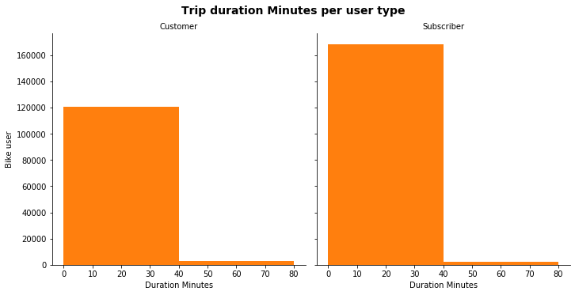

```python
# bike duration per user type by seconds
base_color = sb.color_palette()[1]
g = sb.FacetGrid(bikes_df_clean, col="user_type", margin_titles=True, size=5)
bin_edges = np.arange(0, 120,40)
g.map(plt.hist, "duration_min", color=base_color, bins=bin_edges)
g.set_axis_labels("Duration Minutes", "Bike user")
g.set_titles(col_template = '{col_name}')
g.fig.suptitle('Trip duration Minutes per user type', y=1.03, fontsize=14, fontweight='semibold');
```

## Duration per weekday by minutes

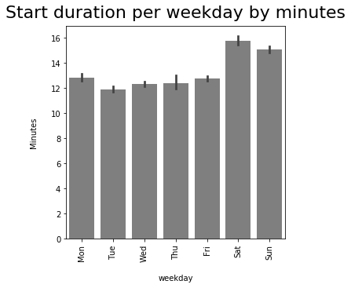

```python
#duration per weekday by minutes, start time
plt.figure(figsize = [5, 5])
base_color = sb.color_palette()[7]
weekday = ['Mon', 'Tue', 'Wed', 'Thu', 'Fri', 'Sat', 'Sun']
sb.barplot(data = bikes_df_clean, x = 'start_time_weekday', y = 'duration_min',
           color = base_color, order= weekday)
plt.xticks(rotation=90)
plt.title('Start duration per weekday by minutes', fontsize=22, y=1.015)
plt.xlabel('weekday', labelpad=16)
plt.ylabel('Minutes', labelpad=16);
plt.show()
```

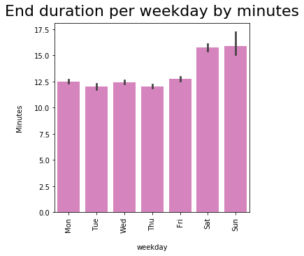

```python
#duration per weekday by minutes, end time
plt.figure(figsize = [5, 5])
base_color = sb.color_palette()[6]
weekday = ['Mon', 'Tue', 'Wed', 'Thu', 'Fri', 'Sat', 'Sun']
sb.barplot(data = bikes_df_clean, x = 'end_time_weekday', y = 'duration_min',
           color = base_color, order= weekday)
plt.xticks(rotation=90)
plt.title('End duration per weekday by minutes', fontsize=22, y=1.015)
plt.xlabel('weekday', labelpad=16)
plt.ylabel('Minutes', labelpad=16);
plt.show()
```

## Duration per weekday by hours

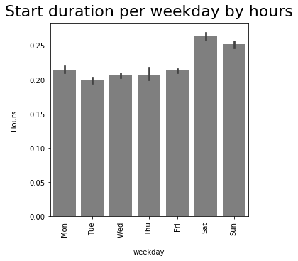

```python
#duration per weekday by hours, start time
plt.figure(figsize = [5, 5])
base_color = sb.color_palette()[7]
weekday = ['Mon', 'Tue', 'Wed', 'Thu', 'Fri', 'Sat', 'Sun']
sb.barplot(data = bikes_df_clean, x = 'start_time_weekday', y = 'duration_hr',
           color = base_color, order= weekday)
plt.xticks(rotation=90)
plt.title('Start duration per weekday by hours', fontsize=22, y=1.015)
plt.xlabel('weekday', labelpad=16)
plt.ylabel('Hours', labelpad=16);
plt.show()
```

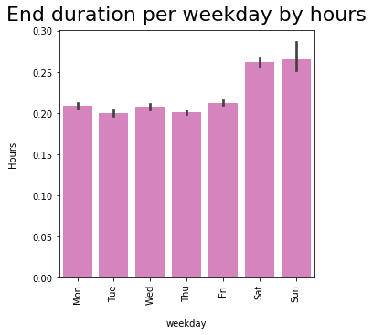

```python
#duration per weekday by hours, end time
plt.figure(figsize = [5, 5])
base_color = sb.color_palette()[6]
weekday = ['Mon', 'Tue', 'Wed', 'Thu', 'Fri', 'Sat', 'Sun']
sb.barplot(data = bikes_df_clean, x = 'end_time_weekday', y = 'duration_hr',
           color = base_color, order= weekday)
plt.xticks(rotation=90)
plt.title('End duration per weekday by hours', fontsize=22, y=1.015)
plt.xlabel('weekday', labelpad=16)
plt.ylabel('Hours', labelpad=16);
plt.show()
```

## Conclusion

This shows bike rides on Saturday and sunday to be higher in both minutes and hours

## Percentage of all bike rides per weekday

```python
#calculate the percentage, start time
trip_by_weekday_df = bikes_df_clean.groupby('start_time_weekday').agg({'bike_id':'count'})
trip_by_weekday_df['perc'] = (trip_by_weekday_df['bike_id']/trip_by_weekday_df['bike_id'].sum())*100
```

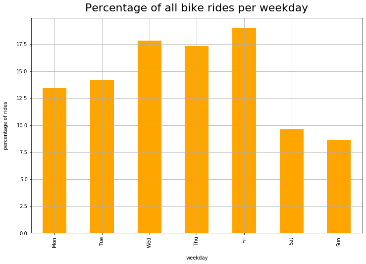

```python
#usage the percentage with weekday for the percentage of bike rides perweek
weekday = ['Mon', 'Tue', 'Wed', 'Thu', 'Fri', 'Sat', 'Sun']
new_color = ['orange', 'orange', 'orange', 'orange', 'orange', 'orange', 'orange']
trip_by_weekday_df.reindex(weekday)['perc'].plot( kind='bar', color=new_color, figsize=(12,8), legend=False)
plt.title('Percentage of all bike rides per weekday', fontsize=22, y=1.015)
plt.xlabel('weekday', labelpad=16)
plt.ylabel('percentage of rides', labelpad=16)
plt.savefig('pic17.png')
plt.grid()
```

```python
#calculate the percentage, end time
trip_by_weekday_df = bikes_df_clean.groupby('end_time_weekday').agg({'bike_id':'count'})
trip_by_weekday_df['perc'] = (trip_by_weekday_df['bike_id']/trip_by_weekday_df['bike_id'].sum())*100
```

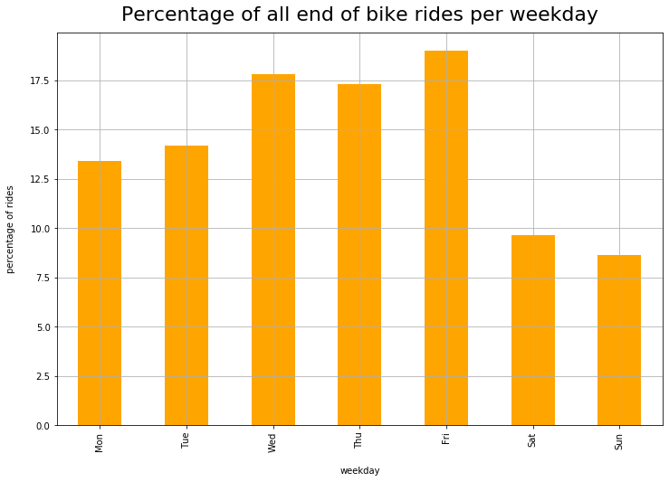

```python
#usage the percentage with weekday for the percentage of bike rides perweek
weekday = ['Mon', 'Tue', 'Wed', 'Thu', 'Fri', 'Sat', 'Sun']
new_color = ['orange', 'orange', 'orange', 'orange', 'orange', 'orange', 'orange']
trip_by_weekday_df.reindex(weekday)['perc'].plot(kind='bar', color=new_color, figsize=(12,8), legend=False)
plt.title('Percentage of all end of bike rides per weekday', fontsize=22, y=1.015)
plt.xlabel('weekday', labelpad=16)
plt.ylabel('percentage of rides', labelpad=16)
plt.savefig('pic17.png')
plt.grid()
```

## Conclusion

Highest percentage of bike rides is on Friday, Wednesday and finally Thursday

### Did you observe any interesting relationships between the other features (not the main feature(s) of interest)?

> I did find interesting for duration with weekday I found Saturday and Sunday to be higher with the output. I was not surprised for Friday however very surprised overall that Wednesday and Thursday were the next weekdays with higher usage.

## Multivariate Exploration

> Create plots of three or more variables to investigate your data even further. Make sure that your investigations are justified, and follow from your work in the previous sections.

## Duration of User per weekday by minutes

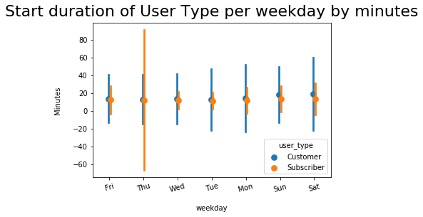

```python
#Take start time, minutes durations and user type to plot
weekday = ['Mon', 'Tue', 'Wed', 'Thu', 'Fri', 'Sat', 'Sun']
sb.pointplot(data = bikes_df_clean, x = 'start_time_weekday', y= 'duration_min', hue = 'user_type',
            ci = 'sd', linestyles ="", dodge = True);
plt.xticks(rotation = 15);
plt.title('Start duration of User Type per weekday by minutes', fontsize=22, y=1.015)
plt.xlabel('weekday', labelpad=16)
plt.ylabel('Minutes', labelpad=16);
```

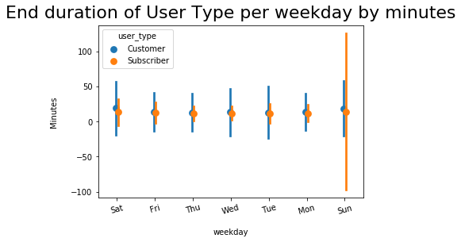

```python
#Take end time, minutes durations and user type to plot
weekday = ['Mon', 'Tue', 'Wed', 'Thu', 'Fri', 'Sat', 'Sun']
sb.pointplot(data = bikes_df_clean, x = 'end_time_weekday', y= 'duration_min', hue = 'user_type',
            ci = 'sd', linestyles ="", dodge = True);
plt.xticks(rotation = 15);
plt.title('End duration of User Type per weekday by minutes', fontsize=22, y=1.015)
plt.xlabel('weekday', labelpad=16)
plt.ylabel('Minutes', labelpad=16);
```

## Duration of User per weekday by hours

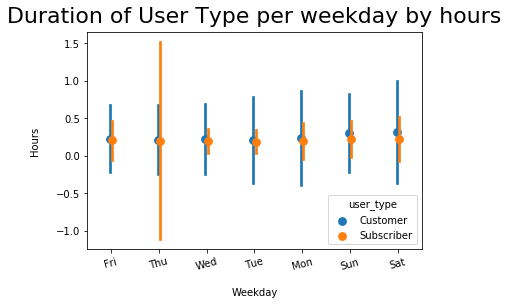

```python
#Take start time, hours durations and user type to plot
weekday = ['Mon', 'Tue', 'Wed', 'Thu', 'Fri', 'Sat', 'Sun']
sb.pointplot(data = bikes_df_clean, x = 'start_time_weekday', y= 'duration_hr', hue = 'user_type',
            ci = 'sd', linestyles ="", dodge = True);
plt.xticks(rotation = 15);
plt.title('Duration of User Type per weekday by hours', fontsize=22, y=1.015)
plt.xlabel('Weekday', labelpad=16)
plt.ylabel('Hours', labelpad=16);
```

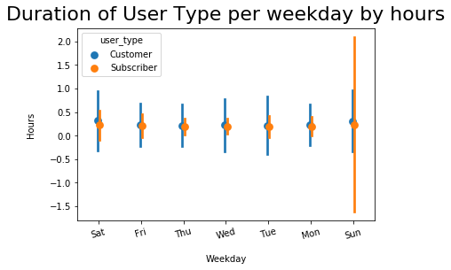

```python
#Take end time, hours durations and user type to plot
weekday = ['Mon', 'Tue', 'Wed', 'Thu', 'Fri', 'Sat', 'Sun']
sb.pointplot(data = bikes_df_clean, x = 'end_time_weekday', y= 'duration_hr', hue = 'user_type',
            ci = 'sd', linestyles ="", dodge = True);
plt.xticks(rotation = 15);
plt.title('Duration of User Type per weekday by hours', fontsize=22, y=1.015)
plt.xlabel('Weekday', labelpad=16)
plt.ylabel('Hours', labelpad=16);
```

## Conclusion

### Were there any interesting or surprising interactions between features?

> At the end of your report, make sure that you export the notebook as an html file from the `File > Download as... > HTML` menu. Make sure you keep track of where the exported file goes, so you can put it in the same folder as this notebook for project submission. Also, make sure you remove all of the quote-formatted guide notes like this one before you finish your report!

```python
bikes_df_clean.to_csv('bikes_df_clean.csv', index=False, encoding = 'utf-8')
```

## Reference

https://matplotlib.org/3.2.0/api/_as_gen/matplotlib.axes.Axes.barh.html#matplotlib.axes.Axes.barh